# PS7_Jeevan

```r
library(NHANES)
library(ggplot2)
df1 = NHANESraw
df = df1[,c("BPSysAve","Age","Weight","Height", "WTMEC2YR","Gender")]
```

```r
df = df[complete.cases(df, df$BPSysAve),]
colSums(is.na(df))
dim(df)
```

**BPSysAve**

0

**Age**

0

**Weight**

0

**Height**

0

**WTMEC2YR**

0

**Gender**

0

1. 14720

2. 6

We have dropped around 25% of our data because we didn't have BPSysAve value in it.

```r
s = sum(df$WTMEC2YR)
df$WTMEC2YR = df$WTMEC2YR/s
```

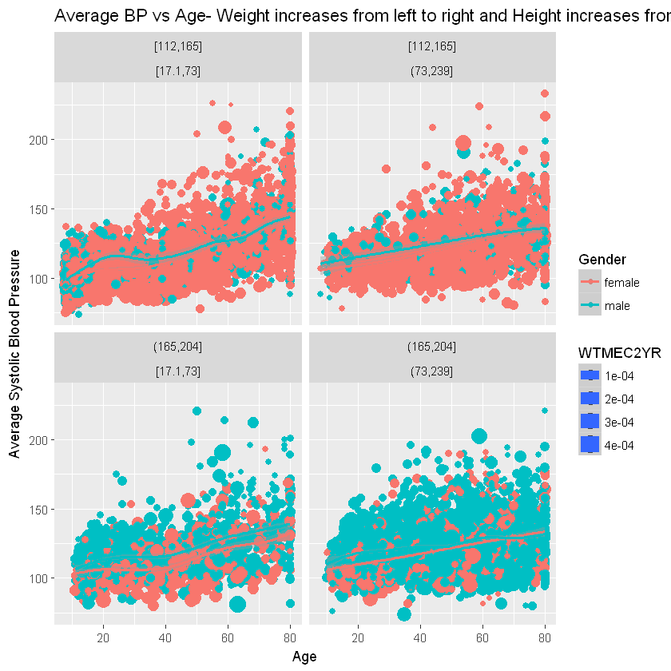

```r
ggplot(df, aes(x=Age,y=BPSysAve,color=Gender,size=WTMEC2YR)) +
  geom_point()  +
  geom_smooth(method.args= list(degree=1),span=0.75) +
  facet_wrap(~(cut_number(Height, n = 2)) + ~(cut_number(Weight,n = 2))) +
ylab("Average Systolic Blood Pressure") +
ggtitle("Average BP vs Age- Weight increases from left to right and Height increases from Top to Bottom")
```

So there is an age and gender factor but the BPSysAve remains the same in all the heighs and weights group and there is an additive shift within gender.

```r
df.lm1 = lm(BPSysAve ~ Age + Gender + Height + Weight  , data = df, weights =WTMEC2YR )
new.grid = expand.grid(Age = seq(10,80,10), Gender = c("female", "male"), Height = c(110,160,210), Weight = c(20,80,240))
new.predict = predict(df.lm1, newdata = new.grid)
new.total = data.frame(new.grid, fit = as.vector(new.predict))
```

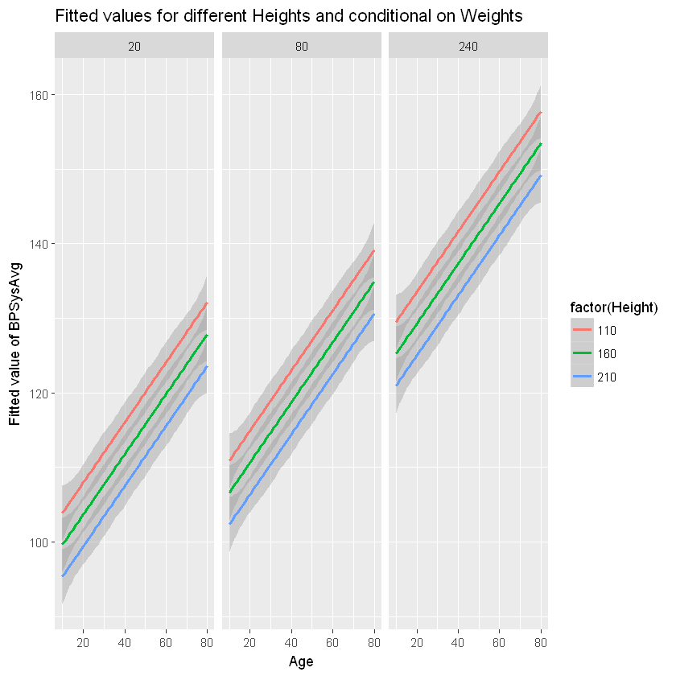

```r
ggplot(new.total, aes(x=Age,y=fit, group = Height, color = factor(Height))) +
   geom_smooth() + facet_wrap(~Weight) + ylab("Fitted value of BPSysAvg") +
ggtitle("Fitted values for different Heights and conditional on Weights")
```

We know that there is just an additive shift for Male and Female BPSysValue. So, we didn't show that in this plot.

# Q2

```r
library(NHANES)
library(ggplot2)
df2 = NHANESraw
dfd = df2[,c("Diabetes","Age","Weight","Height", "WTMEC2YR","Gender")]
dim(dfd)
colSums(is.na(dfd))
dfd = dfd[complete.cases(dfd, dfd$Height),]
colSums(is.na(dfd))
dim(dfd)
```

1. 20293

2. 6

**Diabetes**

833

**Age**

0

**Weight**

888

**Height**

2258

**WTMEC2YR**

0

**Gender**

0

**Diabetes**

0

**Age**

0

**Weight**

0

**Height**

0

**WTMEC2YR**

0

**Gender**

0

1. 18005

2. 6

We have dropped around 10% of our data as we don't have Height or Diabetes or weight values

```r
dfd$Diabetes = as.numeric(dfd$Diabetes)

dfd$Diabetes = dfd$Diabetes - 1
```

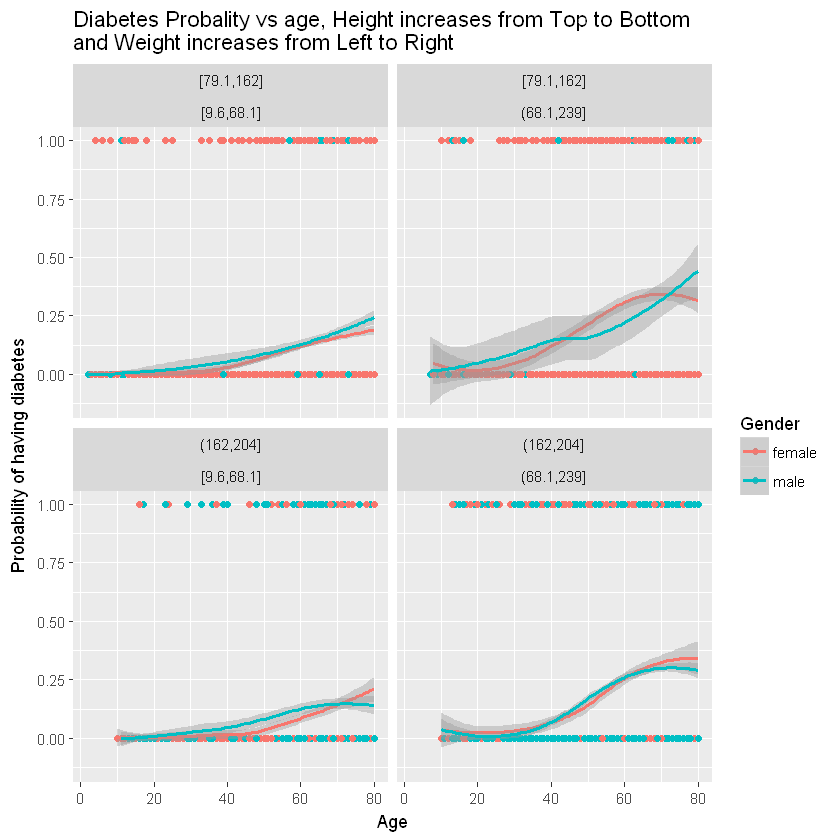

```r
ggplot(dfd,aes(x=Age, y= Diabetes, color = Gender)) + geom_point() +
geom_smooth(method = "loess")+
facet_wrap(~(cut_number(Height, n = 2)) + ~(cut_number(Weight,n = 2))) +
ylab("Probability of having diabetes")+
ggtitle("Diabetes Probality vs age, Height increases from Top to Bottom
and Weight increases from Left to Right")
```

```r
dfd.logit = glm(Diabetes ~ Age + Gender + Height + Weight, family = "binomial", data = dfd)
new.grid = expand.grid(Age = seq(10,80,10), Gender = c("female", "male"), Height = c(80,160,200), Weight = seq(10,240,60))
dfd.pred = predict(dfd.logit, type = "response", newdata = new.grid)
dfd.pred.df = data.frame(new.grid, fit = as.vector(dfd.pred))
```

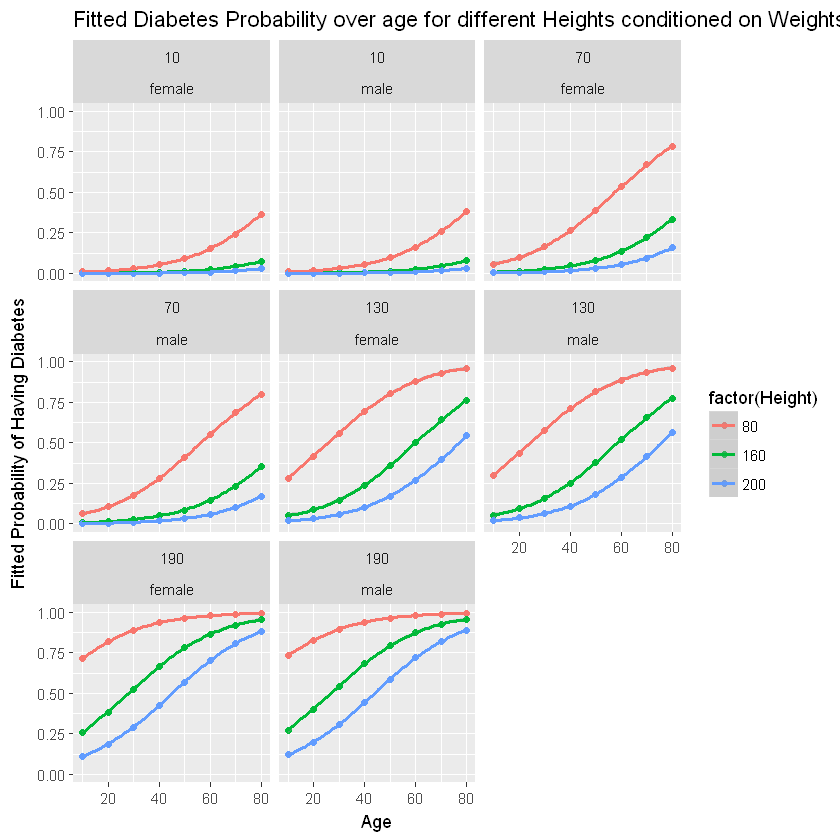

```r
ggplot(dfd.pred.df, aes(x=Age,y=fit,color = factor(Height))) + geom_point() +
   geom_smooth() +
facet_wrap(~(Weight) + ~(Gender)) +
ylab("Fitted Probability of Having Diabetes") +
ggtitle("Fitted Diabetes Probability over age for different Heights conditioned on Weights")
```

We can observe that Diabetes Probability is not depending upon Gender as for Female and Male the distribution is similar.

Over the age the Diabetes Probability of a person increases.

The more the weight of a person the higher the Diabetes Probability.